# 5 - Data Viz with ggplot2 (Plotting Part 2)

Wendy Wagner

2025-3-25

# 1. Introduction

Building on the principles of plotting we covered in part 1, this guide is dedicated mostly to plotting in R, using `ggplot2`-related packages. We will begin to create “pretty” figures with a multitude of customizations. Additionally, we will learn methods to integrate ggplot with other `tidy` functions.

# 2. Getting Started

Before you begin, make sure you have R installed. You can run these commands directly in your R console or within an R script file. Make sure that `library(tidyverse)` and `library(ggplot2)` are installed and called at the beginning of the session.

# 3. Logic of ggplot2

The basic `ggplot2` syntax uses a series of commands, separated by `+` signs:

```
What to plot + how to plot it + various edits & settings
```

Unlike many Base R plots, `ggplot2` works best with data frames.

# 4. Plots in ggplot2

## 4.2 Histogram

Let’s start with a basic histogram using the `Auto` dataset from the `ISLR` package:

```r
library(ggplot2)
library(ISLR)

mydata <- ISLR::Auto
names(mydata)
```

```
## [1] "mpg"          "cylinders"    "displacement" "horsepower"   "weight"
## [6] "acceleration" "year"         "origin"       "name"
```

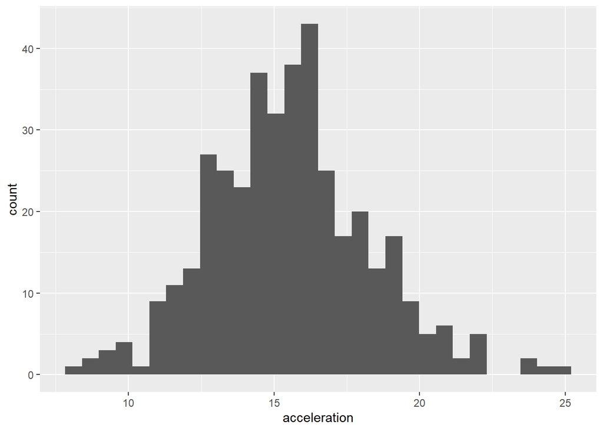

```r
ggplot(mydata, aes(x = acceleration)) + geom_histogram()
```

## 4.3 Bar Chart

For a bar plot, use `geom_bar()`. The `origin` variable in the `Auto` dataset includes three categories:

- American
- European
- Japanese

We first convert `origin` into a factor and then plot it:

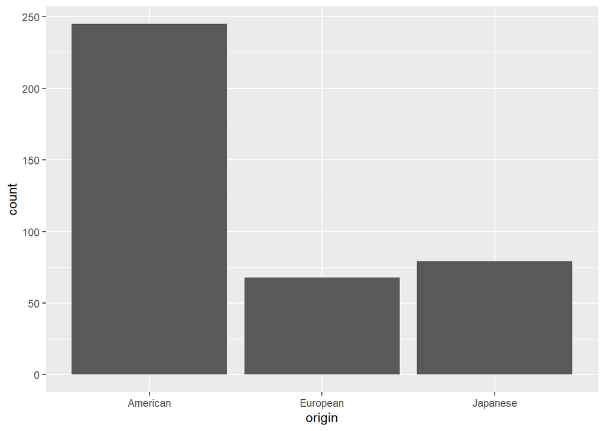

```r
mydata$origin <- factor(mydata$origin,
                        levels = c(1:3),
                        labels = c("American", "European", "Japanese"))

ggplot(mydata, aes(x = origin)) + geom_bar()
```

## 4.4 Scatter Plots

Use `geom_point()` for scatter plots:

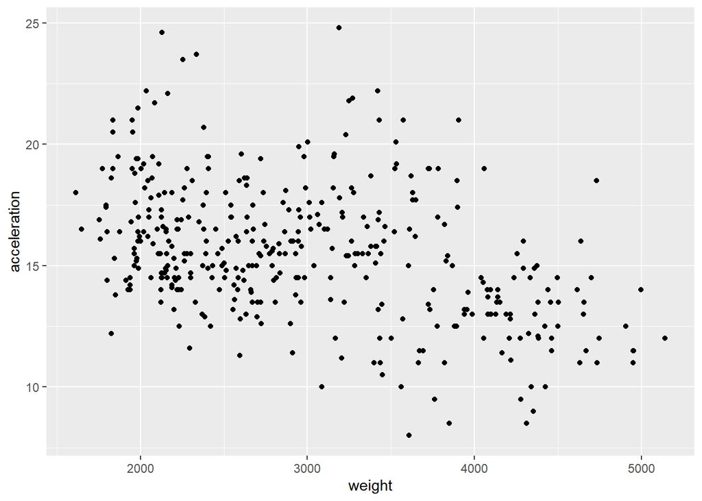

```r
ggplot(mydata, aes(y = acceleration, x = weight)) + geom_point()
```

### Adding Regression Lines

Add a regression line (line of linear association through ordinary least squares estimation) using `stat_smooth()`:

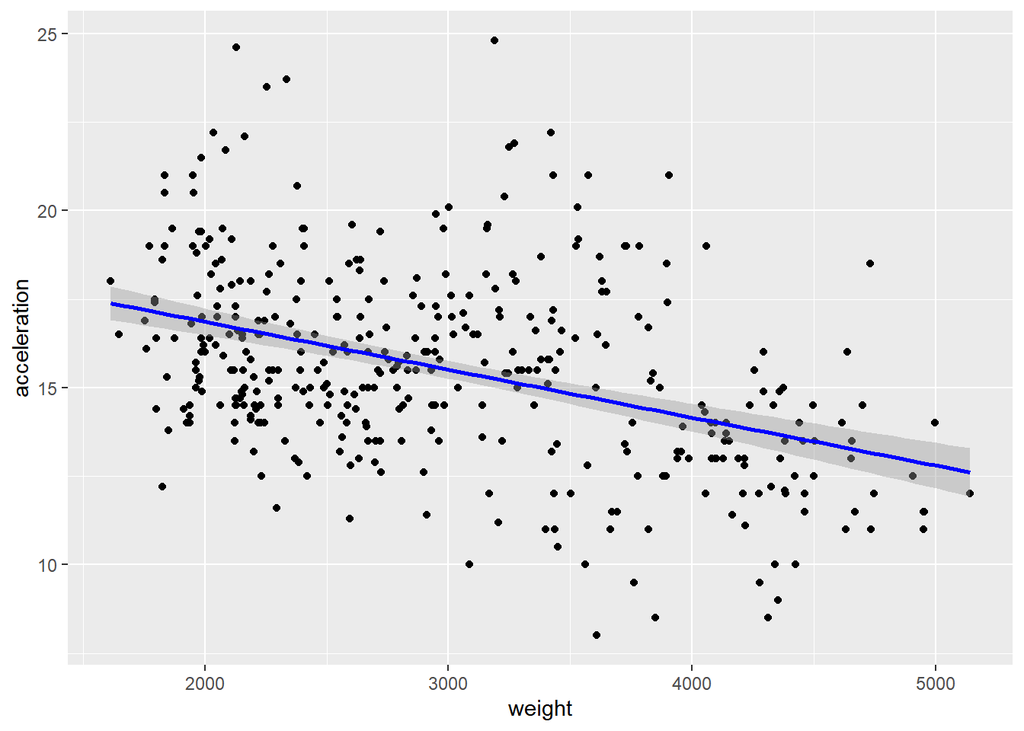

```r
ggplot(mydata, aes(y = acceleration, x = weight)) +
  geom_point() +
  stat_smooth(method = "lm", formula = y ~ x, size = 1, color = "blue")
```

For loess lines:

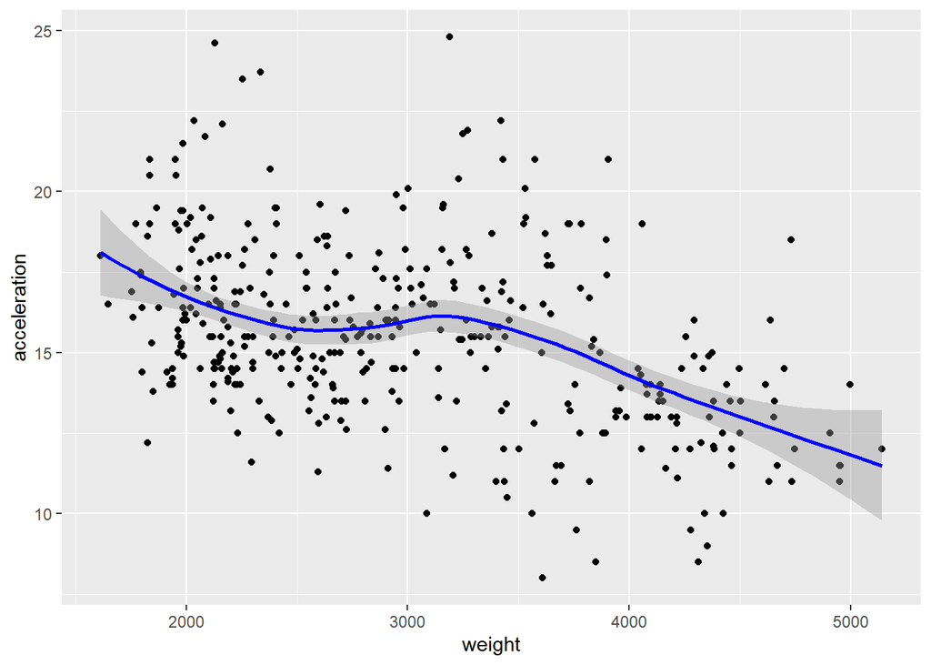

```r
ggplot(mydata, aes(y = acceleration, x = weight)) +
  geom_point() +
  stat_smooth(method = "loess", formula = y ~ x, size = 1, color = "blue")
```

# 5. Working with Groups

## 5.1 Box Plot

Boxplots are useful for comparing the distribution of a continuous variable by group:

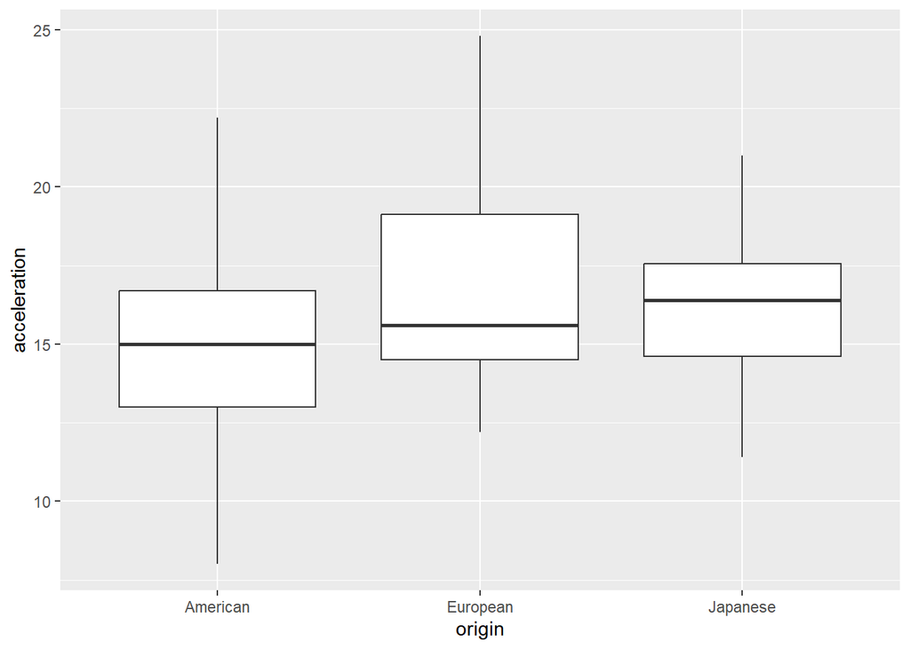

```r
ggplot(mydata, aes(y = acceleration, x = origin)) + geom_boxplot()
```

## 5.2 Violin Plots

Violin plots are also effective:

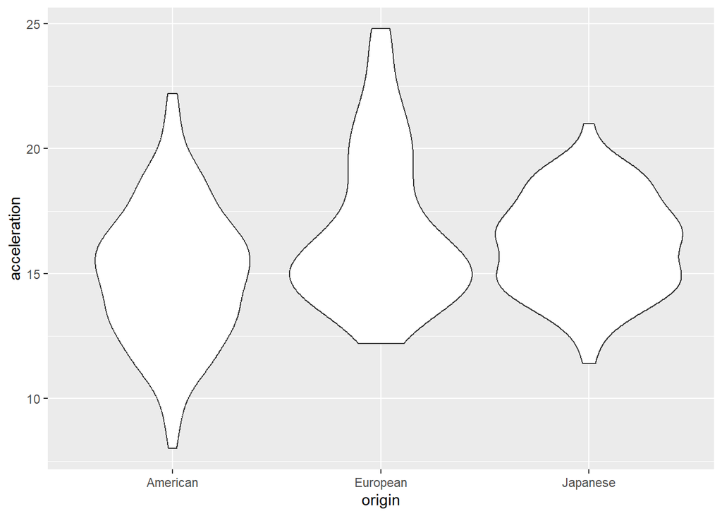

```r
ggplot(mydata, aes(y = acceleration, x = origin)) + geom_violin()
```

## 5.3 Adding mean and median:

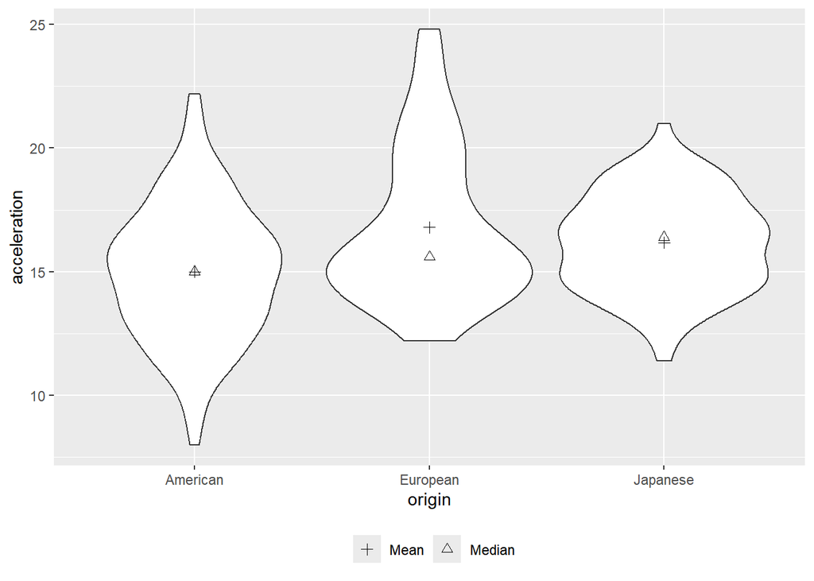

```r
ggplot(mydata, aes(y = acceleration, x = origin)) + geom_violin() +
  scale_shape_manual("", values = c("Mean" = 3, "Median" = 2)) +
  stat_summary(fun.y = mean, geom = "point", aes(shape = "Mean"), size = 2) +
  stat_summary(fun.y = median, geom = "point", aes(shape = "Median"), size = 2) +
  theme(legend.position = "bottom")
```

## 5.4 Group Colors

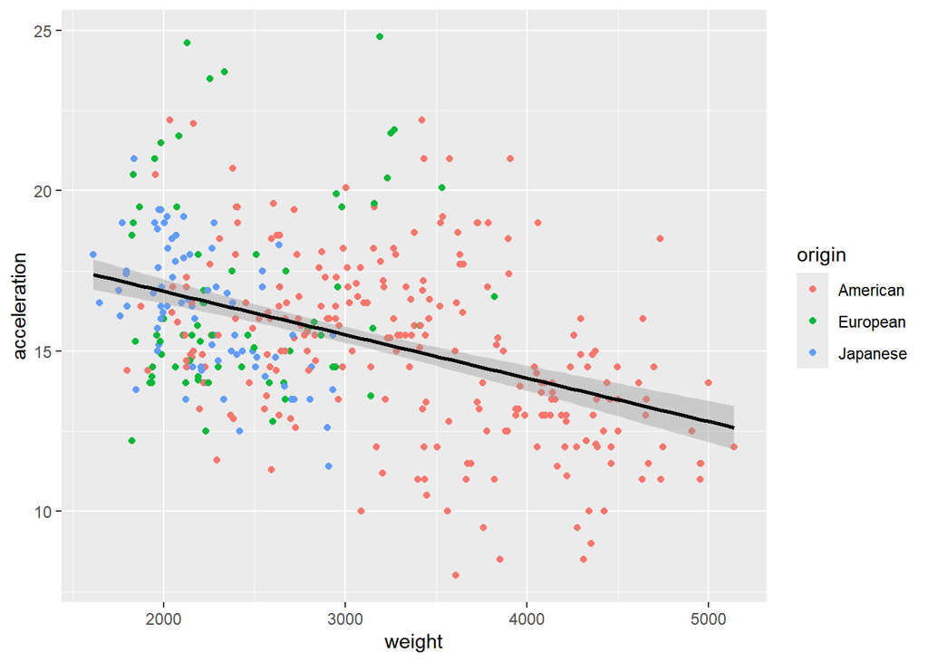

```r
ggplot(mydata, aes(y = acceleration, x = weight, color = origin)) +
  geom_point() +
  stat_smooth(method = 'lm', formula = y ~ x, size = 1, color = "black")
```

## 5.5 Group Panels

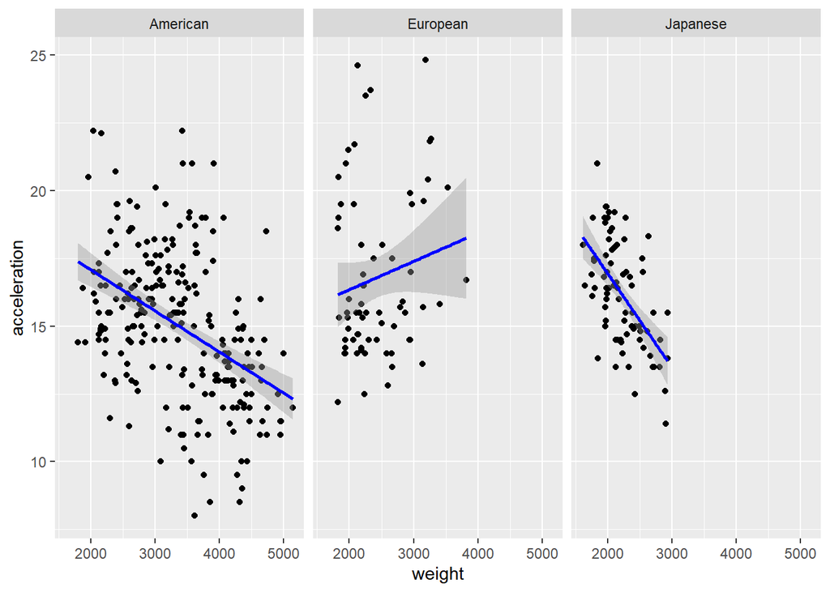

```r
ggplot(mydata, aes(y = acceleration, x = weight)) + geom_point() +
  stat_smooth(method = 'lm', formula = y ~ x, size = 1, color = "blue") +
  facet_grid(. ~ origin)
```

## 5.6 Grouped Bar Chart

If we specify a variable under fill =, we can create a stacked bar-chart. Here we can plot whether or not people have health insurance, by levels of education:

[output not shown]

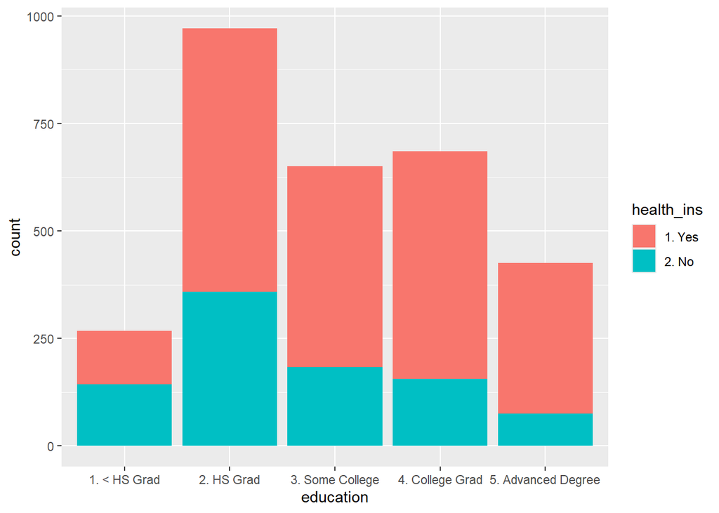

```r
ggplot(wages, aes(x = education, fill = health_ins)) + geom_bar()
```

If we prefer to position our bars side by side, rather than stack them, use position = “dodge” within geom_bar():

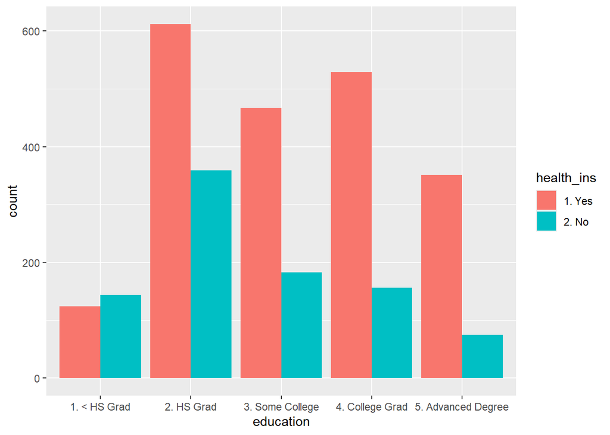

```r
ggplot(wages, aes(x = education, fill = health_ins)) +
  geom_bar(position = "dodge")
```

We can differentiate positions `identity`, `dodge`, and `stack`. By default, multiple bars occupying the same x position will be stacked atop one another by position_stack(). If you want them to be dodged side-to-side, use position_dodge() or position_dodge2(). Finally, position_fill() shows relative proportions at each x by stacking the bars and then standardising each bar to have the same height.

# 6. Editing Graphs

## Titles

Here we are giving our figure a title and adjusting the positioning of the title:

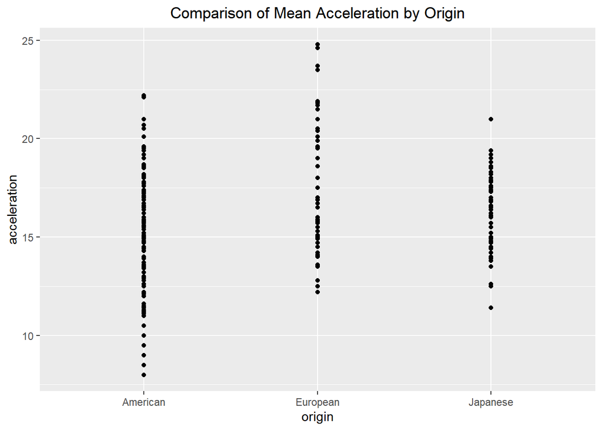

```r
ggplot(mydata, aes(y = acceleration, x = origin)) +
  geom_point() +
  ggtitle("Comparison of Mean Acceleration by Origin") +
  theme(plot.title = element_text(hjust = .5))
```

## Axis Titles

Always make sure to label your axis well. You can do so using `xlab` and `ylab`:

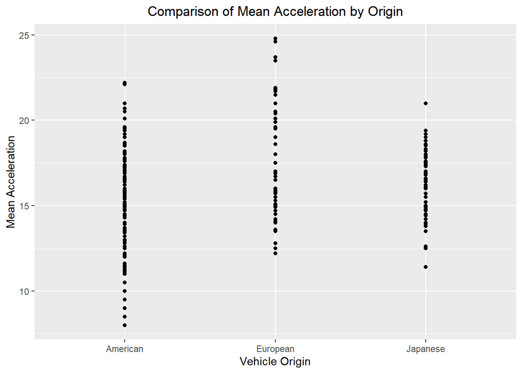

```r
ggplot(mydata, aes(y = acceleration, x = origin)) +
  geom_point() +
  ggtitle("Comparison of Mean Acceleration by Origin") +
  theme(plot.title = element_text(hjust = .5)) +
  xlab("Vehicle Origin") +
  ylab("Mean Acceleration")
```

## Legends

You can control the location and title of the legend as well:

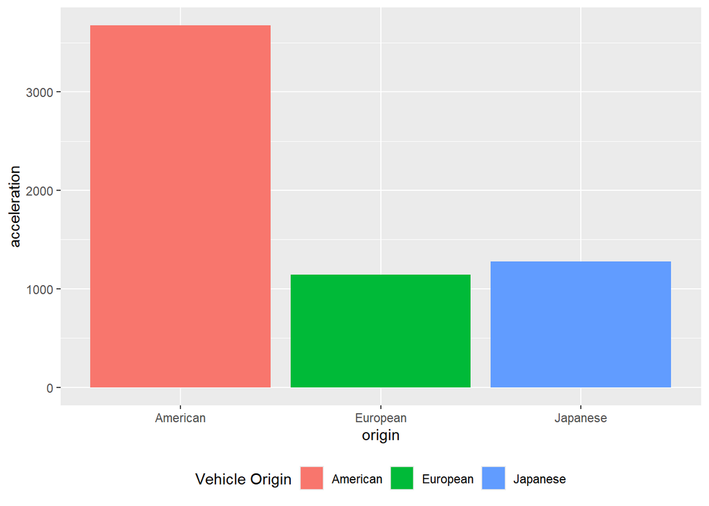

```r
ggplot(mydata, aes(y = acceleration, x = origin, fill = origin)) +
  geom_bar(stat = "identity") +
  theme(legend.position = "bottom") +
  scale_fill_discrete(name = "Vehicle Origin")
```

## Adjusting Text Elements

Finally, you can also control the size of various text elements in your graph, as well the angle, font and so on:

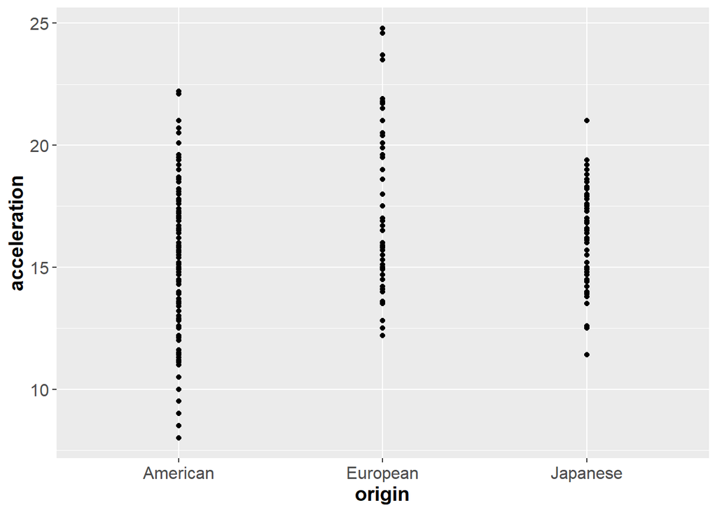

```r
ggplot(mydata, aes(y = acceleration, x = origin)) +
  geom_point() +
  theme(axis.text = element_text(size = 12),
        axis.title = element_text(size = 14, face = "bold"),
        legend.text = element_text(size = 12))
```

## Themes and Styles

Additionally, there are many `styles` available in ggplot to personalize your figure. For example, if you’re unhappy with the colors and prefer a grey-scale bar-chart, use scale_fill_grey():

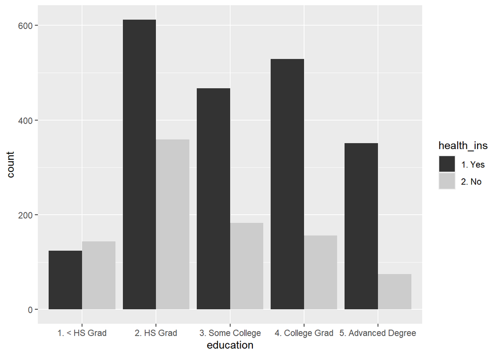

```r
ggplot(wages, aes(x = education, fill = health_ins)) +
  geom_bar(position = "dodge") +
  scale_fill_grey()
```

Or we can play around with the background if we like. For example, use theme_classic() or theme_bw(). Test for yourself what happens if you simply type `+theme_` and take a look at the suggestions. Here we see the black and white theme:

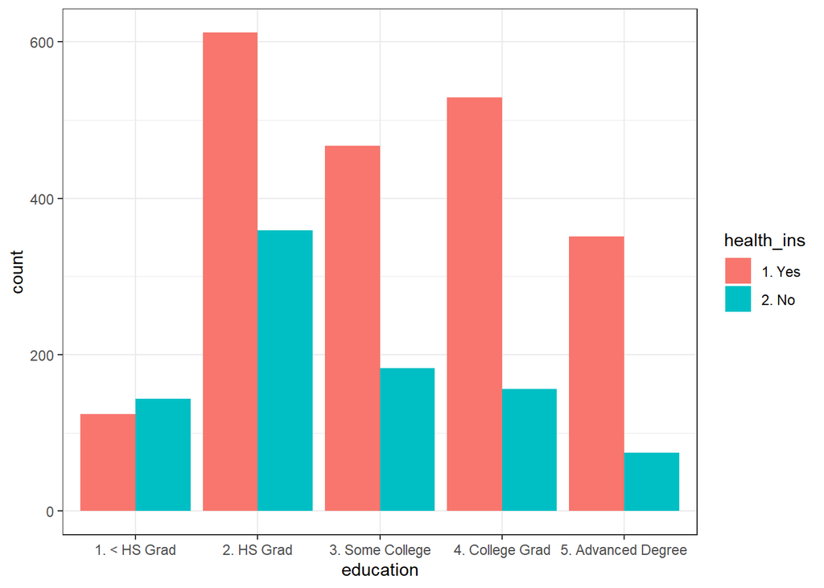

```r
ggplot(wages, aes(x = education, fill = health_ins)) +
  geom_bar(position = "dodge") +
  theme_bw()
```

Or the classic theme:

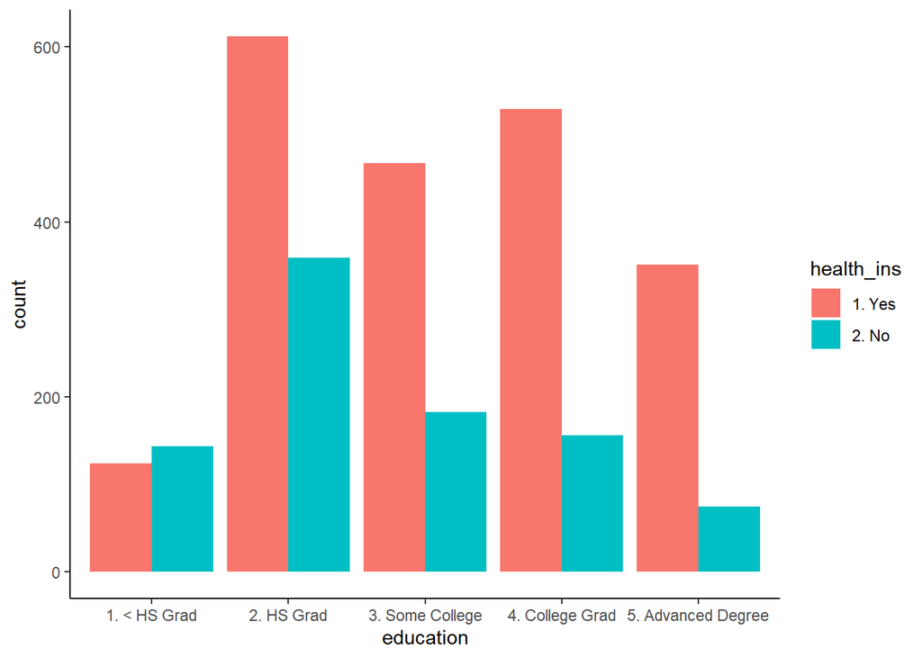

```r
ggplot(wages, aes(x = education, fill = health_ins)) +
  geom_bar(position = "dodge") +
  theme_classic()
```

# 7. Combining dplyr (tidyverse and `%>%`) and ggplot2

We are using the information cars stored as `mydata` earlier in this code.

Most of the time, plots demand a degree of data cleaning, manipulation, subsetting, aggregation before we can create the plot of our dreams. For these purposes, ggplot figures can be integrated with `%>%` operators in a very neat fashion. In this context, we can reference the dataset only once, outside of the ggplot command, altering the code as such:

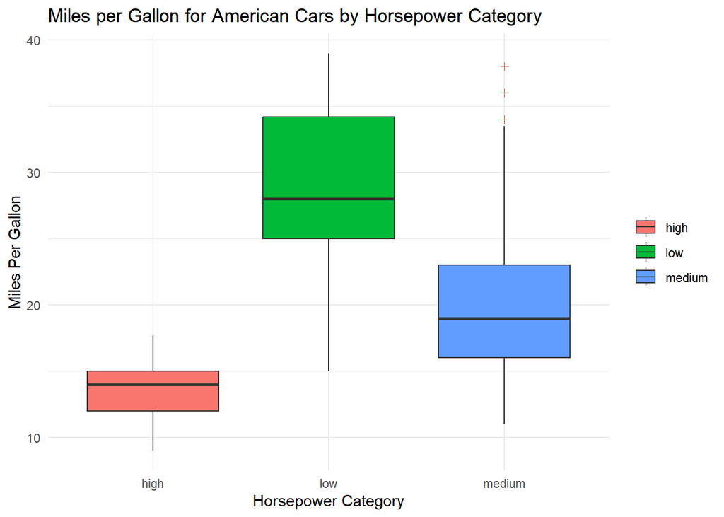

```r
mydata %>%
  filter(origin=="American")%>%
  mutate(hp_cat=case_when(horsepower   <=80 ~ "low",
                          horsepower   >=81 & horsepower    <=150 ~ "medium",
                          horsepower   >=151 ~ "high"))%>%
  ggplot(aes(y=mpg, x=hp_cat, fill=hp_cat))+
  geom_boxplot(outlier.colour = "tomato3", outlier.shape = 3) +   # Having some fun with highlighting outliers differently
  ggtitle("Miles per Gallon for American Cars by Horsepower Category")+
  theme_minimal() +                    # Pretty style choice
  theme(legend.title=element_blank())+  # Removing the legend title, can also remove legend entirely
  labs(x = "Horsepower Category", y = "Miles Per Gallon")
```

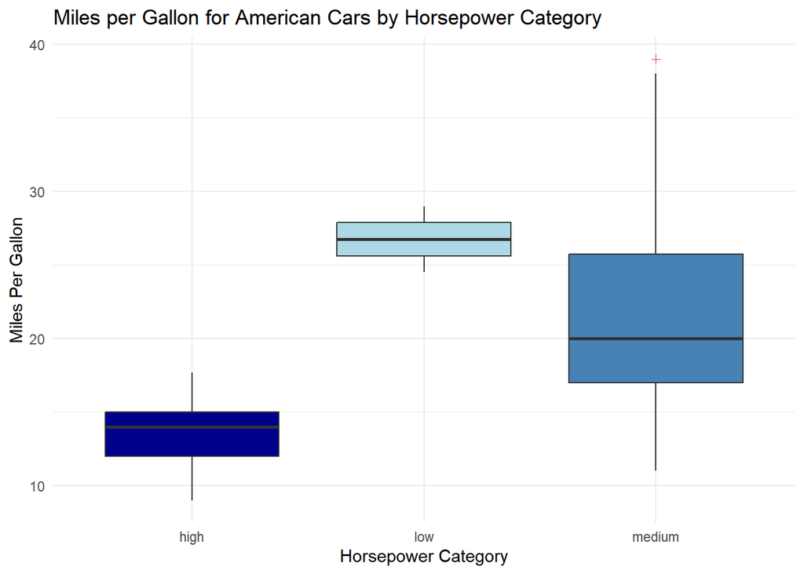

```r
# Or we can further customize coloring:
mydata %>%
  filter(origin=="American")%>%
  mutate(hp_cat=case_when(horsepower<=60 ~ "low",
                          horsepower>=61 & horsepower <=150 ~ "medium",
                          horsepower>=151 ~ "high"))%>%
  ggplot(aes(y=mpg, x=hp_cat, fill=hp_cat))+
  geom_boxplot(outlier.colour = "tomato3", outlier.shape = 3)+   # Having some fun with highlighting outliers differently
  ggtitle("Miles per Gallon for American Cars by Horsepower Category")+
  theme_minimal() +                    # Pretty style choice
  theme(legend.position = "none") +  # Remove legend since fill is redundant with x-axis labels
  labs(x = "Horsepower Category", y = "Miles Per Gallon")+
  scale_fill_manual(values = c("low" = "lightblue", "medium" = "steelblue", "high" = "darkblue")) # Custom blue shades
```

Note that we are not assigning (i.e. using `<-`) for the filter and aggregation operations. This means these operations are only temporary - for the figure we are generating - and not saved into a new data set! Sometimes this is exactly what we want, a non-permanent aggregation for a resulting figure without actually having to aggregate our data or create a new data frame.

# 8. Final Remarks

This is by far not all that ggplot is capable of! But this should give you a solid foundation on which to build and develop increasingly complex plotting code and more and more beautiful figures. Visit the following links to get more information on the vast possibilities with ggplot - and do not shy away from checking out forums for inspiration:

- Find many chart examples on the R Graph Gallery page: https://r-graph-gallery.com/
- See many color options for scale_colour_fill: https://statisticsglobe.com/scale-colour-fill-brewer-rcolorbrewer-package-r
- Download the R color cheat sheet: https://www.nceas.ucsb.edu/sites/default/files/2020-04/colorPaletteCheatsheet.pdf
- Visit the function reference guide for ggplot2: https://ggplot2.tidyverse.org/reference/

You can also view color scales that can be combined with ggplot using package `RColorBrewer`:

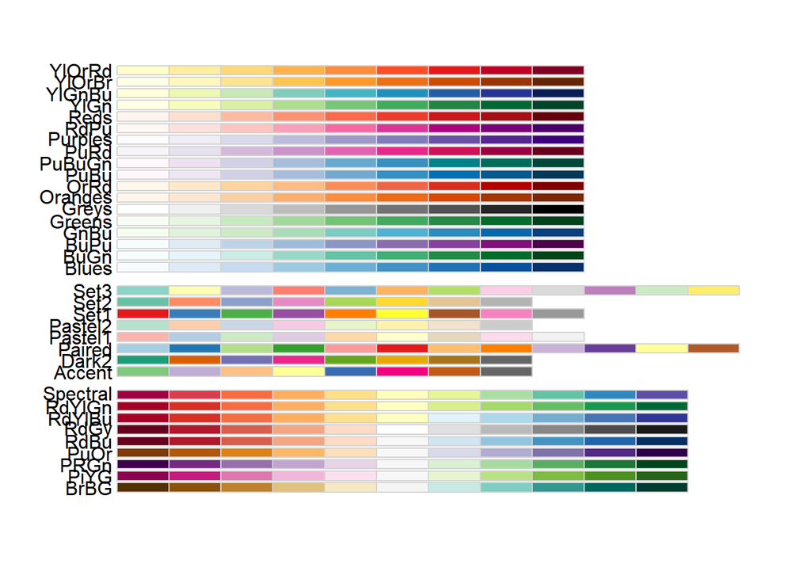

```r
library(RColorBrewer)
par(mar=c(3,4,2,2))
display.brewer.all()
```

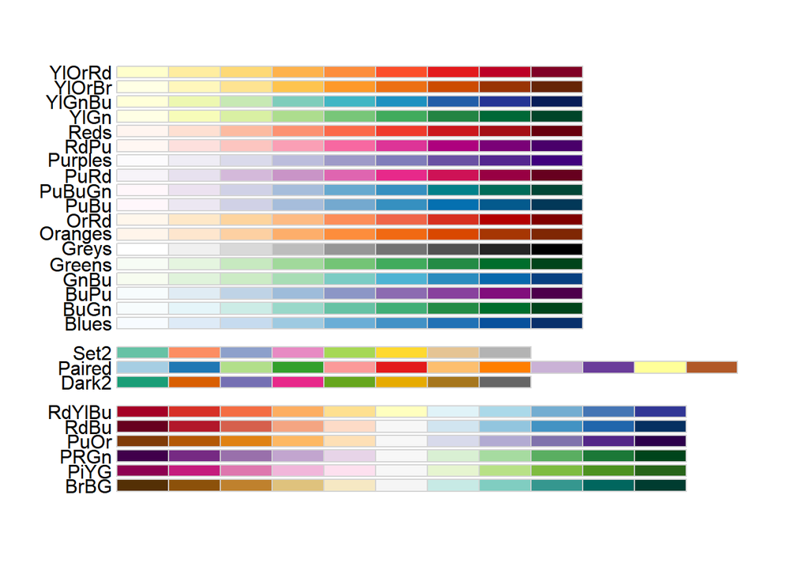

```r
display.brewer.all(colorblindFriendly=TRUE)
```

The possibilities are truly endless!

# 9. Optional Challenge

If you’d like, you know enough at this point to attempt to figure out the code for something we have not explicitly discussed here. Try using the ‘wages’ data and create a *stacked* bar graph where each bar represents 100 % of each `jobclass` broken down by `education` with all text in Times New Roman font. Try recreate the following and, of course, utilizing forums like stackexchange/AI/YouTube is *encouraged*:

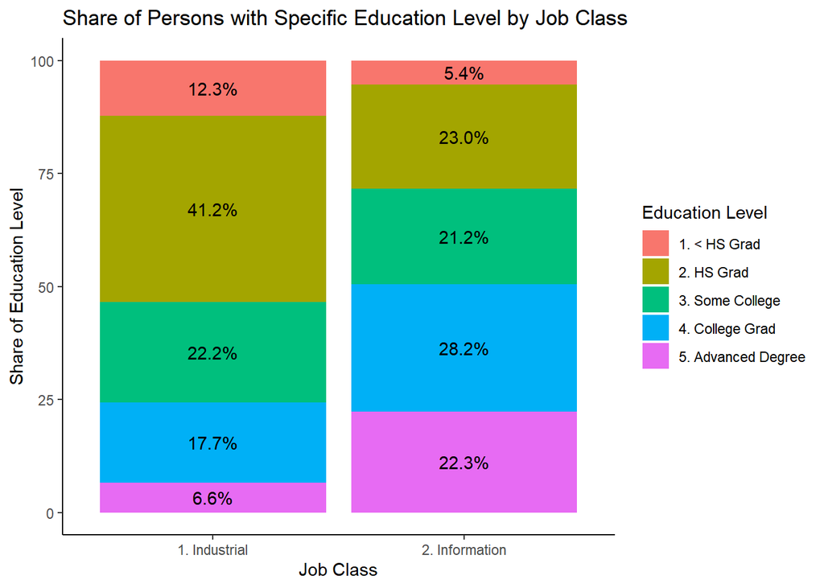